# R Notebook

## Libraries

```r
library(pdftools)
library(tidyverse)
library(magrittr)
library(stringi)
library(tabulizer)
library(cld2)
```

## Company list preparation

### Loading data from GRI db

```r
setwd("../")
gri_reports <- read.csv("reports/GriTempUrlList3.csv") # data from GRI database

# gri_reports %>% count(Country_Organization_Account, sort = T)

gri_companylist <- gri_reports %>% # selecting reports from German companies and those that have been downloaded successfully
  filter(str_detect(Country_Organization_Account,"Germany")) %>%
  filter((dld_status=="FE")|(dld_status=="OK"))

gri_companylist[1:3,2] <-str_remove(gri_companylist[1:3,2],"Drillisch ") #company changed name

gri_companylist2 <- gri_reports %>% # selecting reports from German companies and those that have been downloaded successfully
  filter(str_detect(Country_Organization_Account,"Switzerland")|str_detect(Country_Organization_Account,"Spain")|str_detect(Country_Organization_Account,"Sweden")) %>%
  filter((dld_status=="FE")|(dld_status=="OK"))
```

### Loading data from MarketLine db

```r
pub_companylist <- read.csv("public_german_comp.csv") # data from MarketLine database on German companies
pub_companylist2 <- read.csv("spain_swe_switz.csv") # data from MarketLine database on other EU countries companies

pub_companylist %<>% filter(Company_Type=="Public") %>% select(Company_Name, Annual_Revenue_US.M, No_of_Employees, Market_Capitalization_Million_USD) # selecting columns of interest
pub_companylist2 %<>% filter(Company_Type=="Public") %>% select(Company_Name, Annual_Revenue_US.M, No_of_Employees, Market_Capitalization_Million_USD) # selecting columns of interest

names(pub_companylist)[1] <- "Organization" # renaming "Company_Name" for further joining
names(pub_companylist2)[1] <- "Organization" # renaming "Company_Name" for further joining

pub_companylist %<>% mutate(simp_name=iconv(str_squish(Organization), from="UTF-8", to="ASCII//TRANSLIT")) # convert to one encoding and getting rid of non ascii symbols in names
pub_companylist2 %<>% mutate(simp_name=iconv(str_squish(Organization), from="UTF-8", to="ASCII//TRANSLIT")) # convert to one encoding and getting rid of non ascii symbols in names
```

### Joining two sources: MarketLine & GRI db

```r
my_companylist <- inner_join(gri_companylist,pub_companylist, by="Organization")
my_companylist2 <- inner_join(gri_companylist2,pub_companylist2, by="Organization")

my_companylist <- full_join(my_companylist,my_companylist2)

my_companylist %>% distinct(Organization)
```

## Text extraction

```r
my_companylist %<>% filter(Publication_Year==2020)

# Making the fullpath
saving_dir <- "reports"
my_companylist %<>% mutate(fullpath=str_c(saving_dir, ffolder, filename, sep = "/"))

# my_companylist %<>% mutate(text=extract_text(fullpath)) #this worked but now it doesn't no idea why. had to replace with humble for loop

setwd("../")
for (i in 1:nrow(my_companylist)) {
  my_companylist$text[i] <- extract_text(my_companylist$fullpath[i])
}

my_companylist %<>% mutate(lang=detect_language(text))

write_csv(my_companylist, "my_companylist.csv")
```

## Translate non-english text

```r
library(translateR)
library(udpipe)

# dl <- udpipe_download_model(language = "german")
# udmodel_ger <- udpipe_load_model(file = dl$file_model)

my_companylist_trans <- my_companylist %>% filter(!lang=="en")

#need to split text into sentences as whole text translation gives httpheader error. using udpipe for that

# up_ger <- udpipe_annotate(udmodel_ger, x = my_companylist_trans$text, doc_id = my_companylist_trans$fullpath)
# up_ger <- as.data.frame(up_ger)

to_translate1 <- up_ger %>% filter(doc_id=="reports/covestro_ag/2020/zusammengefasster_lagebericht_2019_inklusive_erganzender_nachhaltigkeitsinformationen.pdf")
to_translate2 <- up_ger %>% filter(doc_id=="reports/tag_immobilien_ag/2020/potenziale_verwirklichen_nachhaltigkeitsbericht_2019.pdf")
to_translate3 <- up_ger %>% filter(doc_id=="reports/swiss_prime_site_ag/2020/geschaftsbericht_2019.pdf")

to_translate1 <- unique(to_translate1["sentence"])
to_translate2 <- unique(to_translate2["sentence"])
to_translate3 <- unique(to_translate3["sentence"])

#translated1 <-translate(dataset=to_translate1,
#            content.field="sentence",
#            source.lang="de",
#            target.lang="en",
#            google.api.key="mykey")

#translated2 <-translate(dataset=to_translate2,
#            content.field="sentence",
#            source.lang="de",
#            target.lang="en",
#            google.api.key="mykey")

#translated3 <-translate(dataset=to_translate3,
#            content.field="sentence",
#            source.lang="de",
#            target.lang="en",
#            google.api.key="mykey")


#my_companylist$text[3] <- capture.output(cat(translated1$translatedContent))
#my_companylist$text[8] <- capture.output(cat(translated2$translatedContent))
#my_companylist$text[12] <- capture.output(cat(translated3$translatedContent))

my_companylist$text[3] %>% glimpse()
```

```
 chr "COMBINED MANAGEMENT REPORT 2019 INCLUDING ADDITIONAL SUSTAINABILITY INFORMATION COMBINED MANAGEMENT REPORT 2019"| __truncated__
```

```r
write_csv(my_companylist, "my_companylist.csv")
```

## Annotating text

```r
udmodel <- udpipe_load_model(file = "english-ewt-ud-2.5-191206.udpipe")

#up <- udpipe_annotate(udmodel, x = my_companylist$text, doc_id = my_companylist$Organization)
#up <- as.data.frame(up)

up %>% str()
```

```
'data.frame':   907524 obs. of  14 variables:
 $ doc_id       : chr  "1&1 AG" "1&1 AG" "1&1 AG" "1&1 AG" ...
 $ paragraph_id : int  1 1 1 1 1 1 1 1 1 1 ...
 $ sentence_id  : int  1 1 1 1 1 1 1 1 1 1 ...
 $ sentence     : chr  "SUSTAINABILITY REPORT 2019 1&1 DRILLISCH AG SUSTAINABILITY REPORT 2019 2 KEY FIGURES" "SUSTAINABILITY REPORT 2019 1&1 DRILLISCH AG SUSTAINABILITY REPORT 2019 2 KEY FIGURES" "SUSTAINABILITY REPORT 2019 1&1 DRILLISCH AG SUSTAINABILITY REPORT 2019 2 KEY FIGURES" "SUSTAINABILITY …
 $ token_id     : chr  "1" "2" "3" "4" ...
 $ token        : chr  "SUSTAINABILITY" "REPORT" "2019" "1&1" ...
 $ lemma        : chr  "SUSTAINABILITY" "report" "2019" "1&1" ...
 $ upos         : chr  "INTJ" "VERB" "NUM" "NUM" ...
 $ xpos         : chr  "UH" "VB" "CD" "CD" ...
 $ feats        : chr  NA "Mood=Imp|VerbForm=Fin" "NumType=Card" "NumType=Card" ...
 $ head_token_id: chr  "2" "0" "8" "5" ...
 $ dep_rel      : chr  "discourse" "root" "nummod" "nummod" ...
 $ deps         : chr  NA NA NA NA ...
 $ misc         : chr  NA "SpacesAfter=\\s\\n" "SpacesAfter=\\n" NA ...
```

## Express network analysis of most cooccurrences of Nouns & Adjectives within sentence

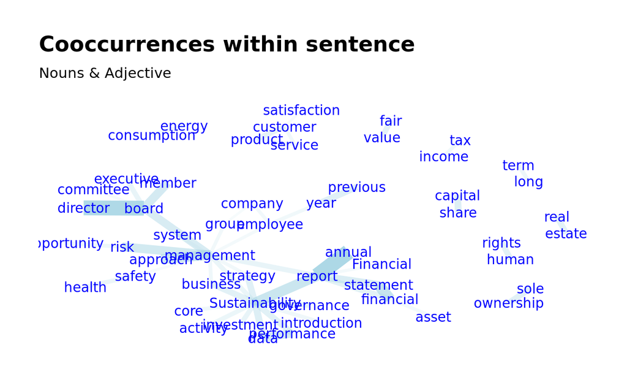

## Loading topic-specific dictionaries

```r
dict_emp <-read_csv("dict/employee_dict.csv",col_names="word")
dict_soc_com <-read_csv("dict/social_community_dict.csv",col_names="word")
dict_hr <-read_csv("dict/humanrights_dict.csv",col_names="word")
dict_env <-read_csv("dict/environment_dict.csv",col_names="word")
```

## Counting dictionary-based words and bigrams & preparing dataset for analisys

```r
my_dataset <- my_companylist %>% select(Organization, Market_Capitalization_Million_USD, No_of_Employees)

stats_emp <- subset(up, token %in% dict_emp$word)
tt <- stats_emp %>% group_by(doc_id) %>% count(token) %>% summarise(totalwords_emp=sum(n))
my_dataset %<>% merge(tt, by.x="Organization", by.y="doc_id")

stats_soc_com <- subset(up, token %in% dict_soc_com$word)
tt <- stats_soc_com %>% group_by(doc_id) %>% count(token) %>% summarise(totalwords_soc_com=sum(n))
my_dataset %<>% merge(tt, by.x="Organization", by.y="doc_id")


stats_hr <- subset(up, token %in% dict_hr$word)
tt <- stats_hr %>% group_by(doc_id) %>% count(token) %>% summarise(totalwords_hr=sum(n))
my_dataset %<>% merge(tt, by.x="Organization", by.y="doc_id")

stats_env <- subset(up, token %in% dict_env$word)
tt <- stats_env %>% group_by(doc_id) %>% count(token) %>% summarise(totalwords_env=sum(n))
my_dataset %<>% merge(tt, by.x="Organization", by.y="doc_id")

tt2 <- up %>% subset(upos %in% c("NOUN","ADJ", "VERB", "AUX", "DET", "ADP", "PROPN")) %>% group_by(doc_id) %>% count(token) %>% summarise(totalwords=sum(n))
my_dataset %<>% merge(tt2, by.x="Organization", by.y="doc_id")

my_dataset %<>% mutate(share_tw_emp=totalwords_emp/totalwords,
                       share_tw_soc_com=totalwords_soc_com/totalwords,
                       share_tw_hr=totalwords_hr/totalwords,
                       share_tw_env=totalwords_env/totalwords)

names(my_dataset)[2] <- "mark_cap"

my_dataset %>% glimpse()
```

```
Rows: 13
Columns: 12
$ Organization       <chr> "1&1 AG", "Allianz SE", "Bucher Industries AG", "Coca-Cola HBC AG", "Covestro AG", "E.ON SE", "Evonik Industries AG", "Francotyp-P…
$ mark_cap           <dbl> 4115.08, 89881.16, 4395.20, 8842.36, 9837.74, 31558.48, 13332.26, 48.90, 3724.16, 6935.36, 3259.60, 8095.90, 6469.90
$ No_of_Employees    <int> 3170, 150269, 13404, 26767, 17883, 73072, 32891, 1003, 13468, 1455, 1363, 7828, 9565
$ totalwords_emp     <int> 306, 551, 133, 851, 554, 437, 522, 284, 391, 645, 249, 1117, 557
$ totalwords_soc_com <int> 325, 1158, 103, 633, 303, 353, 484, 193, 473, 492, 161, 1044, 644
$ totalwords_hr      <int> 154, 295, 79, 708, 255, 234, 280, 134, 241, 418, 108, 977, 221
$ totalwords_env     <int> 558, 1522, 177, 1177, 828, 735, 1007, 493, 648, 1559, 362, 959, 640
$ totalwords         <int> 25638, 43289, 9633, 98279, 52952, 41241, 52553, 36264, 28457, 78495, 24027, 92045, 40212
$ share_tw_emp       <dbl> 0.011935408, 0.012728407, 0.013806706, 0.008659022, 0.010462305, 0.010596251, 0.009932830, 0.007831458, 0.013740029, 0.008217084, …
$ share_tw_soc_com   <dbl> 0.012676496, 0.026750445, 0.010692412, 0.006440847, 0.005722163, 0.008559443, 0.009209750, 0.005322083, 0.016621569, 0.006267915, …
$ share_tw_hr        <dbl> 0.006006709, 0.006814664, 0.008200976, 0.007203981, 0.004815682, 0.005673965, 0.005327955, 0.003695125, 0.008468918, 0.005325180, …
$ share_tw_env       <dbl> 0.02176457, 0.03515905, 0.01837434, 0.01197611, 0.01563680, 0.01782207, 0.01916161, 0.01359475, 0.02277120, 0.01986114, 0.01506638…
```

```r
library(tidytext)
bigrams_new <- my_companylist %>%
  unnest_tokens(bigram,text,token = "ngrams", n=2)

stats_emp2 <- subset(bigrams_new, bigram %in% dict_emp$word)
stats_soc_com2 <- subset(bigrams_new, bigram %in% dict_soc_com$word)
stats_hr2 <- subset(bigrams_new, bigram %in% dict_hr$word)
stats_env2 <- subset(bigrams_new, bigram %in% dict_env$word)

print(c(nrow(stats_emp2), nrow(stats_soc_com2), nrow(stats_hr2), nrow(stats_env2)))
```

```
[1]   2   2   0 309
```

```r
tt3 <- stats_env2 %>% group_by(Organization) %>% count(bigram) %>% summarise(totalwords_env2=sum(n))
my_dataset_temp <-my_dataset

my_dataset_temp %<>% left_join(tt3, by="Organization")

my_dataset_temp %<>% mutate(totalwords_env=totalwords_env+totalwords_env2)
```

## Applying lm

```r
my_lm1 <- lm(mark_cap ~ totalwords_emp+totalwords_soc_com+totalwords_hr+totalwords_env,
             data = my_dataset)

my_lm2 <- lm(mark_cap ~ share_tw_emp+share_tw_soc_com+share_tw_hr+share_tw_env,
             data = my_dataset)

my_lm3 <- lm(mark_cap ~ No_of_Employees+totalwords,
             data = my_dataset)

summary(my_lm1)
```

```
Call:
lm(formula = mark_cap ~ totalwords_emp + totalwords_soc_com +
    totalwords_hr + totalwords_env, data = my_dataset)

Residuals:
     Min       1Q   Median       3Q      Max
-15197.0  -8537.2   -264.5   4253.4  23372.7

Coefficients:
                    Estimate Std. Error t value Pr(>|t|)
(Intercept)         -514.174  12125.591  -0.042  0.96722
totalwords_emp       -78.675     64.849  -1.213  0.25966
totalwords_soc_com    76.883     21.084   3.647  0.00653 **
totalwords_hr         -6.418     58.037  -0.111  0.91467
totalwords_env        23.732     14.737   1.610  0.14598
---
Signif. codes:  0 ‘***’ 0.001 ‘**’ 0.01 ‘*’ 0.05 ‘.’ 0.1 ‘ ’ 1

Residual standard error: 13870 on 8 degrees of freedom
Multiple R-squared:  0.7754,    Adjusted R-squared:  0.6632
F-statistic: 6.907 on 4 and 8 DF,  p-value: 0.01043
```

```r
summary(my_lm2)
```

```
Call:
lm(formula = mark_cap ~ share_tw_emp + share_tw_soc_com + share_tw_hr +
    share_tw_env, data = my_dataset)

Residuals:
   Min     1Q Median     3Q    Max
-20429  -8495   1118   5575  22692

Coefficients:
                 Estimate Std. Error t value Pr(>|t|)
(Intercept)         19647      37126   0.529    0.611
share_tw_emp     -6073099    3334429  -1.821    0.106
share_tw_soc_com  3278204    1796606   1.825    0.105
share_tw_hr        709583    2951833   0.240    0.816
share_tw_env      1205570    1369126   0.881    0.404

Residual standard error: 14890 on 8 degrees of freedom
Multiple R-squared:  0.7412,    Adjusted R-squared:  0.6118
F-statistic: 5.728 on 4 and 8 DF,  p-value: 0.01779
```

```r
summary(my_lm3)
```

```
Call:
lm(formula = mark_cap ~ No_of_Employees + totalwords, data = my_dataset)

Residuals:
    Min      1Q  Median      3Q     Max
-8726.6 -3010.2   258.5  3367.0  6364.0

Coefficients:
                  Estimate Std. Error t value Pr(>|t|)
(Intercept)     -1.237e+03  3.189e+03  -0.388    0.706
No_of_Employees  5.596e-01  3.566e-02  15.692 2.27e-08 ***
totalwords       1.527e-02  5.564e-02   0.274    0.789
---
Signif. codes:  0 ‘***’ 0.001 ‘**’ 0.01 ‘*’ 0.05 ‘.’ 0.1 ‘ ’ 1

Residual standard error: 5171 on 10 degrees of freedom
Multiple R-squared:  0.961, Adjusted R-squared:  0.9532
F-statistic: 123.1 on 2 and 10 DF,  p-value: 9.052e-08
```

## Check for liniarity

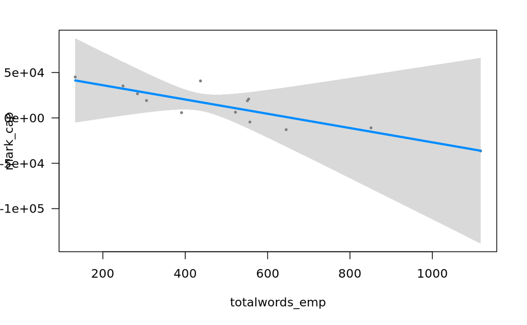

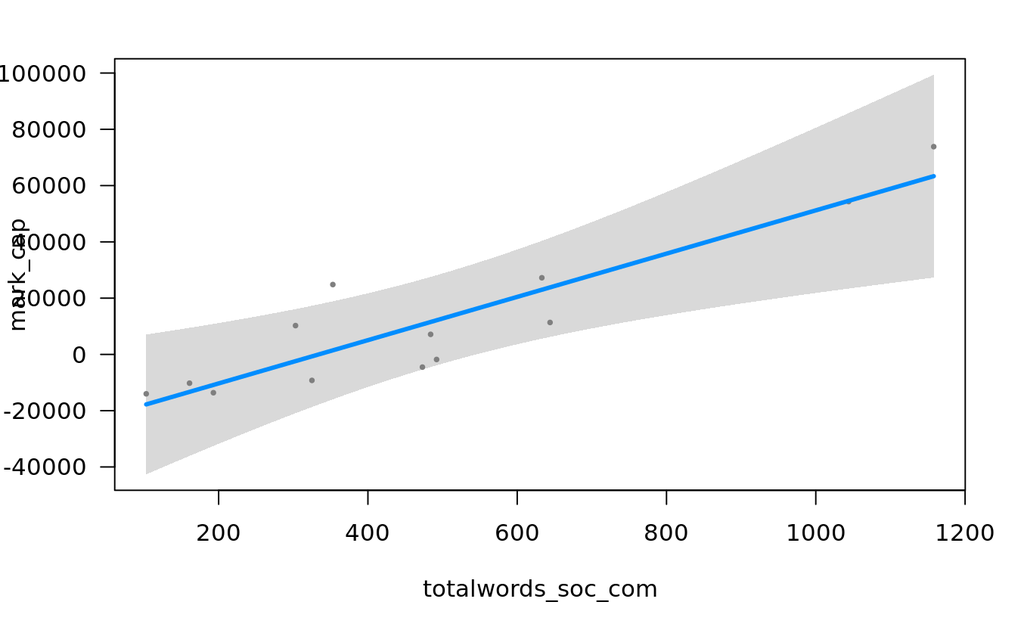

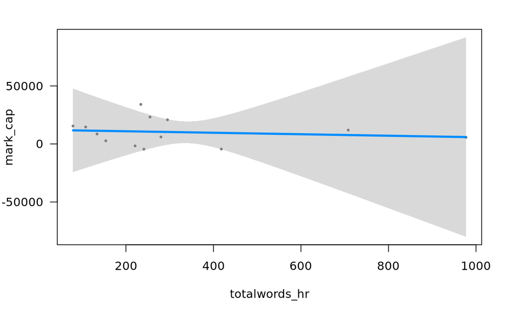

```r
library(visreg)

visreg(my_lm1)
```

[figure not shown]

```r
NA
```

## Quick check

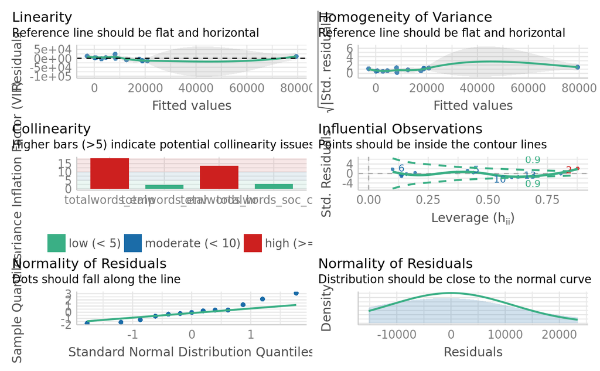

```r
library(performance)
library(see)
check_model(my_lm1)
```

## Checking lm

### Outliers

or results_object %>% ols_plot_cooksd_chart()

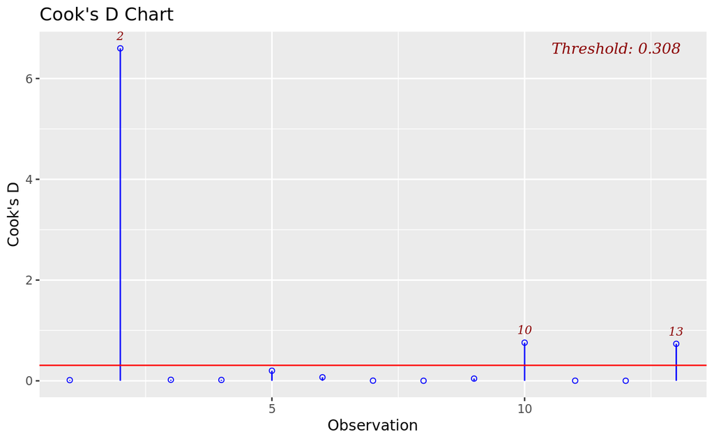

```r
library(olsrr)
my_lm1 %>% ols_plot_cooksd_chart()
```

### Removing ouliers and running regression again

```r
my_dataset2 <- my_dataset[-c(2),]
my_lm1_2 <- lm(mark_cap ~ totalwords_emp+totalwords_soc_com+totalwords_hr+totalwords_env,
             data = my_dataset2)
summary(my_lm1_2)
```

```
Call:
lm(formula = mark_cap ~ totalwords_emp + totalwords_soc_com +
    totalwords_hr + totalwords_env, data = my_dataset2)

Residuals:
    Min      1Q  Median      3Q     Max
-7077.4 -3478.3 -2112.5   115.6 22754.7

Coefficients:
                   Estimate Std. Error t value Pr(>|t|)
(Intercept)        1756.080   8433.093   0.208    0.841
totalwords_emp       33.555     57.638   0.582    0.579
totalwords_soc_com   -9.523     31.399  -0.303    0.770
totalwords_hr       -23.176     40.572  -0.571    0.586
totalwords_env        1.591     12.449   0.128    0.902

Residual standard error: 9609 on 7 degrees of freedom
Multiple R-squared:  0.1039,    Adjusted R-squared:  -0.4081
F-statistic: 0.203 on 4 and 7 DF,  p-value: 0.9288
```

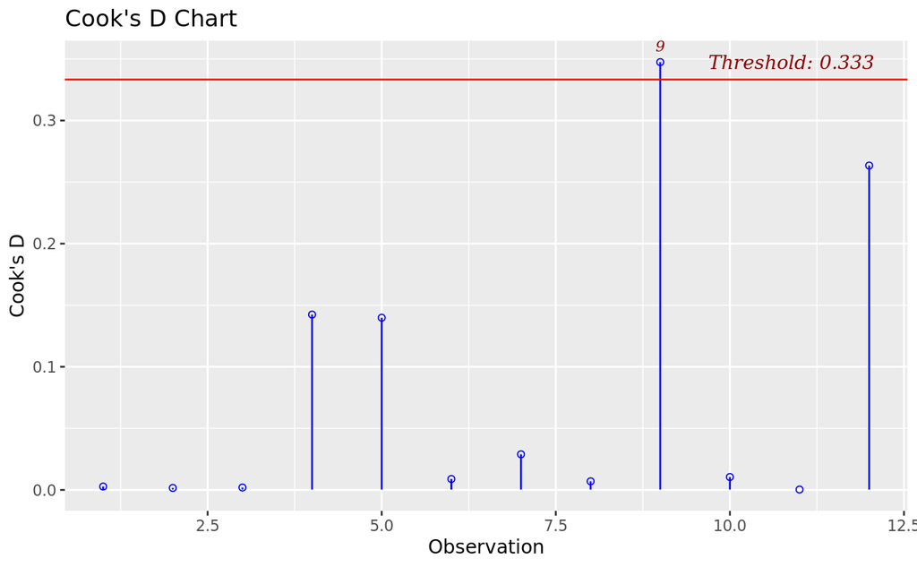

```r
my_lm1_2 %>% ols_plot_cooksd_chart()
```

Results became worse. Decided not to delete outliers.

### Multicollinearity

Use of function ols_vif_tol() in package olsrr

```r
my_lm1 %>% ols_vif_tol()
```

| Variables | Tolerance | VIF |
| --- | --- | --- |
| totalwords_emp | 0.05501719 | 18.176137 |
| totalwords_soc_com | 0.35324750 | 2.830876 |
| totalwords_hr | 0.07258897 | 13.776197 |
| totalwords_env | 0.42401241 | 2.358422 |

```r
NA
```

VIF of totalwords_emp and totalwords_hr is higher than 5, hence multicollinearity observed (corresponds to in quick check results)

### Residuals

#### Normally distributed residuals:

Function ols_test_normality() in package olsrr directly applicable to regression results object (No systematic biases & just random noise)

```r
my_lm1 %>% ols_test_normality()
```

```
-----------------------------------------------
       Test             Statistic       pvalue
-----------------------------------------------
Shapiro-Wilk              0.9602         0.7575
Kolmogorov-Smirnov        0.1228         0.9759
Cramer-von Mises          1.1026         0.0010
Anderson-Darling          0.1982         0.8554
-----------------------------------------------
```

Normal distribution hypothesis not to be rejected because p-value is above 0.01 in Shapiro-Wilk test

#### Heteroscedasticity

Function ols_test_breusch_pagan() in package olsrr directly applicable to regression results object

```r
my_lm1 %>% ols_test_breusch_pagan()
```

```
 Breusch Pagan Test for Heteroskedasticity
 -----------------------------------------
 Ho: the variance is constant
 Ha: the variance is not constant

                Data
 ------------------------------------
 Response : mark_cap
 Variables: fitted values of mark_cap

        Test Summary
 -----------------------------
 DF            =    1
 Chi2          =    0.05946361
 Prob > Chi2   =    0.8073457
```

Prob>Chi2 = p-value p-value above 0.01 implying homoscedasticity cannot be rejected #### Running multiple versions of model 1

```r
library(stargazer)

my_lm1_emp <- lm(mark_cap ~ totalwords_emp+totalwords_soc_com+totalwords_env,
             data = my_dataset)
my_lm1_sc <- lm(mark_cap ~ totalwords_soc_com+totalwords_env,
             data = my_dataset)
my_lm1_hr <- lm(mark_cap ~ totalwords_hr+totalwords_soc_com+totalwords_env,
             data = my_dataset)
#my_lm1_env <- lm(mark_cap ~ totalwords_env, data = my_dataset)

stargazer(my_lm1_emp,my_lm1_sc,my_lm1_hr,my_lm1, type = "text")
```

```
=======================================================================================================
                                                    Dependent variable:
                    -----------------------------------------------------------------------------------
                                                         mark_cap
                             (1)                  (2)                  (3)                  (4)
-------------------------------------------------------------------------------------------------------
totalwords_emp           -85.350***                                                       -78.675
                          (22.353)                                                       (64.849)

totalwords_hr                                                       -71.962***            -6.418
                                                                     (21.751)            (58.037)

totalwords_soc_com        77.054***              35.555             70.036***            76.883***
                          (19.840)              (25.488)             (20.840)            (21.084)

totalwords_env             24.276*               12.059               16.674              23.732
                          (13.107)              (19.518)             (13.890)            (14.737)

Constant                   317.565            -12,650.720          -10,603.560           -514.174
                         (8,974.025)          (12,755.130)         (9,052.648)         (12,125.590)

-------------------------------------------------------------------------------------------------------
Observations                 13                    13                   13                  13
R2                          0.775                0.411                0.734                0.775
Adjusted R2                 0.700                0.293                0.646                0.663
Residual Std. Error  13,085.190 (df = 9)  20,093.100 (df = 10) 14,227.240 (df = 9)  13,868.340 (df = 8)
F Statistic         10.340*** (df = 3; 9) 3.486* (df = 2; 10)  8.284*** (df = 3; 9) 6.907** (df = 4; 8)
=======================================================================================================
Note:                                                                       *p<0.1; **p<0.05; ***p<0.01
```

## Drafts

```r
stargazer(my_lm1)
```

```
% Table created by stargazer v.5.2.2 by Marek Hlavac, Harvard University. E-mail: hlavac at fas.harvard.edu
% Date and time: Mon, Jan 31, 2022 - 15:53:04
\begin{table}[!htbp] \centering
  \caption{}
  \label{}
\begin{tabular}{@{\extracolsep{5pt}}lc}
\\[-1.8ex]\hline
\hline \\[-1.8ex]
 & \multicolumn{1}{c}{\textit{Dependent variable:}} \\
\cline{2-2}
\\[-1.8ex] & mark\_cap \\
\hline \\[-1.8ex]
 totalwords\_emp & $-$78.675 \\
  & (64.849) \\
  & \\
 totalwords\_soc\_com & 76.883$^{***}$ \\
  & (21.084) \\
  & \\
 totalwords\_hr & $-$6.418 \\
  & (58.037) \\
  & \\
 totalwords\_env & 23.732 \\
  & (14.737) \\
  & \\
 Constant & $-$514.174 \\
  & (12,125.590) \\
  & \\
\hline \\[-1.8ex]
Observations & 13 \\
R$^{2}$ & 0.775 \\
Adjusted R$^{2}$ & 0.663 \\
Residual Std. Error & 13,868.340 (df = 8) \\
F Statistic & 6.907$^{**}$ (df = 4; 8) \\
\hline
\hline \\[-1.8ex]
\textit{Note:}  & \multicolumn{1}{r}{$^{*}$p$<$0.1; $^{**}$p$<$0.05; $^{***}$p$<$0.01} \\
\end{tabular}
\end{table}
```

Ex-ante checks Number of observations Type of dependent variable Linearity Ex-post checks with potentially model refinement Multicollinearity Outlier Normal distribution of residuals Heteroscedasticity Autocorrelation (spatial/temporal)